# MATH6157 – Applied Statistical

Assessed Assignment 2

Ronald M. Gualan Saavedra (MSc. Data Science)

MSc. Data Science

First, the random number seed is set to the University ID of the author

```r
library(MASS)
set.seed(29021812)
bacteria_ds <- bacteria
bacteria_ds$ynum[bacteria_ds$y=='y'] <- 1
bacteria_ds$ynum[bacteria_ds$y=='n'] <- 0
```

### 1. Mixed models

**The bacteria data set (available from the MASS library in R) gives the results of tests for the presence (y) or absence (n) of the bacteria H. influenzae in a group of 50 children (ID) in Australia. Each child was given one of three treatments (trt), placebo, drug, drug+, and measurements were taken at weeks 0, 2, 4, 6 and 11.**

**a) Fit various generalised linear models (GLMs) to the data using week, trt and ID as explanatory variables, and comment on their fit, e.g. using summary statistics and/or graphical summaries. Produce a normal probability plot for the residuals from at least one of the models you fit, and comment on its usefulness for binary (ungrouped) data, giving reasons for your comments.**

Some logistic regression models (GLM) were created trying some combinations of predictors. A logistic regression is a suitable choice for the bacteria dataset because the predictand *y* is a binary variable.

```r
bacteria.glm0 <- glm(y~1, family=binomial, data=bacteria)
bacteria.glm1 <- glm(y~trt, family=binomial, data=bacteria)
bacteria.glm2 <- glm(y~trt+week, family=binomial, data=bacteria)
bacteria.glm3 <- glm(y~trt+week+ID, family=binomial, data=bacteria)
#summary(bacteria.glmD)
```

After some GLMs have been fit with the bacteria dataset, it is time to evaluate how weel these models fit the data. The deviance is one measure of how well the model fits the data. We can compare the performance of the fitted models using a Chi-squared test with the anova method.

```r
anova(bacteria.glm0, bacteria.glm1, bacteria.glm2, bacteria.glm3, test="Chisq")
```

```
Analysis of Deviance Table

Model 1: y ~ 1
Model 2: y ~ trt
Model 3: y ~ trt + week
Model 4: y ~ trt + week + ID
  Resid. Df Resid. Dev Df Deviance  Pr(>Chi)
1       219     217.38
2       217     210.72  2    6.656 0.0358674 *
3       216     203.81  1    6.914 0.0085524 **
4       169     118.51 47   85.295 0.0005339 ***
---
Signif. codes:  0 ‘***’ 0.001 ‘**’ 0.01 ‘*’ 0.05 ‘.’ 0.1 ‘ ’ 1
```

According to this test, the model 4 (with more predictors) is significant because it reduces considerable the Residual deviance in comparison with the simpler models. This is a expected result because model 4 uses a considerable amount of parameters derived from the dummy variables associated with the predictor ID. Model 4 is a model with a naive fixed effect for the individuals in the study, and therefore it can perform predictive inference only for those individuals.

The pseudo **Pseudo $R^2$** metric [McFadden1974] is used to evaluate the amount of variation in the predictand that can be explained by the predictors.

```r
library(BaylorEdPsych)
model_names = c('glm1','glm2','glm3')
pseudo_R2 = c(PseudoR2(bacteria.glm1)[1],
             PseudoR2(bacteria.glm2)[1],
             PseudoR2(bacteria.glm3)[1])
table_pseudo_R2 = data.frame(model_names, pseudo_R2)
table_pseudo_R2
```

| model_names | pseudo_R2 |
| --- | --- |
| glm1 | 0.03061908 |
| glm2 | 0.06242570 |
| glm3 | 0.45481252 |

Unlike models glm1 and glm2, the pseudo R2 metric for the third model (0.45481252) is relatively good.

Now the Hosmer-Lemeshow goodness-of-fit test is used. Hosmer-Lemeshow test is useful for unreplicated datasets or for datasets that contain just a few replicated observations [[PennState-Stats501]](https://onlinecourses.science.psu.edu/stat501). This is the case for the bacteria dataset.

```r
library(ResourceSelection)
hoslem.vals = c((hoslem.test(bacteria.glm1$y, fitted(bacteria.glm1)))$p.value,
                (hoslem.test(bacteria.glm2$y, fitted(bacteria.glm2)))$p.value,
                (hoslem.test(bacteria.glm3$y, fitted(bacteria.glm3)))$p.value)
table_hoslem = data.frame(model_names, hoslem.vals)
table_hoslem
```

| model_names | hoslem.vals |
| --- | --- |
| glm1 | 1.0000000 |
| glm2 | 0.4520122 |
| glm3 | 0.9996947 |

By using the Hosmer-Lemeshow goodness-of-fit test, we can interpret that glm2 presents no evidence of lack-of-fit. The other models, however, seem not be wrong.

Another relevant way to assess the goodness-of-fit of a regression model is by is looking at the residual plots.

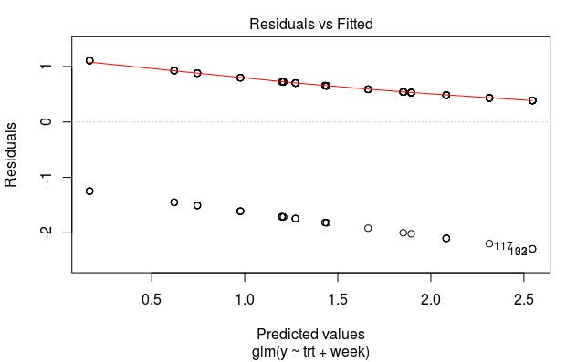

```r
plot(bacteria.glm2, which=1);
```

*Normal probability plot for the residuals*

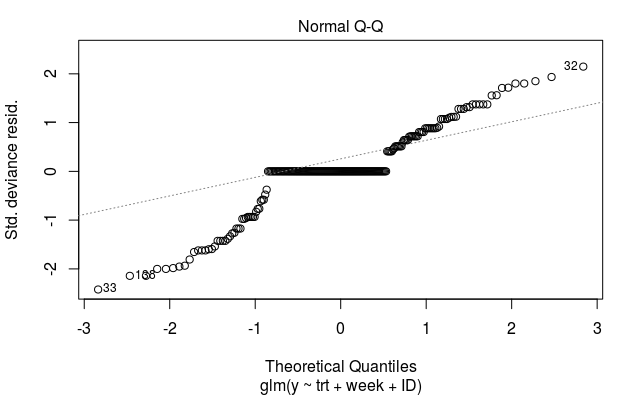

```r
plot(bacteria.glm3,which=2)
```

The Normal Q-Q shows that the deviance residuals are not normally distributed. However, the deviance residuals don’t have to be normally distributed for this regression model. Thus, this plot is not relevant for a logistic regression model.

**(b) Now fit various generalised linear mixed models (GLMMs), including random effects. Assess the fit of each model you try. Qualitatively compare your models to the best GLM fit (i.e. informally compare them)**

```r
library(lme4) # lme4 package for mixed model fitting
bacteria.lmm <- lmer(ynum ~ week + (week | ID), data = bacteria) # REML fitting is the default
```

```
Error in eval(predvars, data, env) : object 'ynum' not found
```